# Unit 5 Case Study: Exposure and Influence

ECI 589 Social Network Analysis and Education

Data Science in Education Using R

April 5, 2022

## 1. PREPARE

Our brief case study for Unit 5 is adapted from an exercise on network influence included in the appendix of [Data Science in Education Using R](https://datascienceineducation.com/c20.html#c20c). In this case study we explore the process of network influence, which is the flip side of the network selection processes we examined in our previous case study. Both of these processes are commonly the focus of statistical analyses of networks. Selection and influence, however, do not interact independently and often affect each other reciprocally (Xu, Frank, & Penuel, 2018).

Let’s first quickly define these two processes:

- **Selection**: the process of choosing relationships
- **Influence**: the process of how our social relationships affect behavior

### 1a. Research Question

In Unit 5, we will briefly examine a hypothetical example of peer influence on attitudes towards STEM careers among a small group of friends. Specifically, we will try to answer the following question:

> Are student’ attitudes towards careers in STEM influenced by the attitudes of their friends?

### 1b. Load Libraries

While selection and influence processes are complex, it is possible to study them using data about people’s relationships and behavior. Happily, the use of these methods has expanded along with R. In fact, long-standing R packages have become some of the best tools for studying social networks. Additionally, while there are many nuances to studying selection and influence, these are models that can be carried out with relatively simple modeling techniques like linear regression, as we’ll see later in this case study.

#### 👉 Your Turn ⤵

To begin, load the the following packages that will be using for our analysis of network influence:

- tidyverse
- tidygraph
- ggraph
- [moderndive](https://github.com/moderndive/moderndive#moderndive-r-package-)

```r
# YOUR CODE HERE
library(tidyverse)
library(tidygraph)
library(ggraph)
library(moderndive)
```

## 2. WRANGLE

- One **edgelist** that contains the *nominator* and *nominee* for a relationship. For example, if Stefanie says that José is her friend, then Stefanie is the nominator and José the nominee. Our edgelist will also contain variable indicating the weight, or strength, of their relation.
- Two **nodelists** indicating the values of some behavior - an outcome - at two different time points. In our case, these values will represent a measure of students’ attitudes towards careers in STEM.

### 2a. Create an Edgelist

First let’s create an edgelist with three variables for a nominator, nominee, and strength of the relation. Run the following code to create [tibble](https://tibble.tidyverse.org) – a tidy table or data frame – that contains information about each friendship dyad in our network with a corresponding strength of “1”, which simply indicates the presence or absence of a tie:

```r
student_edges <- tibble(nominator = c(2, 1, 3, 1, 2, 6, 3, 5, 6, 4, 3, 4),
                        nominee = c(1, 2, 2, 3, 3, 3, 4, 4, 4, 5, 6, 6),
                        relate = c(1, 1, 1, 1, 1, 1, 1, 1, 1, 1, 1, 1) )

student_edges
```

```
## # A tibble: 12 × 3
##    nominator nominee relate
##        <dbl>   <dbl>  <dbl>
##  1         2       1      1
##  2         1       2      1
##  3         3       2      1
##  4         1       3      1
##  5         2       3      1
##  6         6       3      1
##  7         3       4      1
##  8         5       4      1
##  9         6       4      1
## 10         4       5      1
## 11         3       6      1
## 12         4       6      1
```

### 2a. Create Nodelists

Next, let’s create a data frame, or tibble, that contains the nominee and the values of a behavior at the first time point. For our hypothetical example, our `time_1` variable represents a composite score for each students’ attitude towards STEM careers at the beginning of the semester and measured on a scale of -3 (very negative) to 3 (very positive).

```r
nominee_data <- tibble(nominee = c(1, 2, 3, 4, 5, 6),
                       time_1 = c(2.4, 2.6, 1.1, -0.5, -3, -1)
                       )

nominee_data
```

```
## # A tibble: 6 × 2
##   nominee time_1
##     <dbl>  <dbl>
## 1       1    2.4
## 2       2    2.6
## 3       3    1.1
## 4       4   -0.5
## 5       5   -3
## 6       6   -1
```

We will use this data later in our Explore section to create a new measure called an “exposure term” that captures the extent to which an individual is “exposed” to some attribute or characteristic there alters in the network.

#### 👉 Your Turn ⤵

Create a third data frame for data collected at the end of the semester on students’ attitudes towards STEM careers called `nominator_data`. Your output should look something like this:

| nominator | time_2 |
| --- | --- |
| 1 | 2.0 |
| 2 | 2.0 |
| 3 | 1.0 |
| 4 | -0.5 |
| 5 | -2.0 |
| 6 | -0.5 |

```r
# YOUR CODE HERE
nominator_data <- tibble(nominator = c(1, 2, 3, 4, 5, 6),
                         time_2 = c(2, 2, 1, -0.5, -2, -0.5)
                         )

nominator_data
```

```
## # A tibble: 6 × 2
##   nominator time_2
##       <dbl>  <dbl>
## 1         1    2
## 2         2    2
## 3         3    1
## 4         4   -0.5
## 5         5   -2
## 6         6   -0.5
```

### 2c. Create Network with Attributes

Recall from previous units that we introduced the {tidygraph} package for preparing and summarizing network data. Similar to previous units, we will use the `tbl_graph()` function to convert our `student_edges` and `nominee_data` into a network graph object, by including the following arguments and supplying the appropriate code:

- `edges =` expects a data frame, in our case `student_edges`, containing information about the edges in the graph. The nodes of each edge must either be in a `to` and `from` column, or in the two first columns like the data frame we provided.
- `nodes =` expects a data frame, in our case `nominee_data`, containing information about the nodes in the graph.
- `directed =` specifies whether the constructed graph be directed.

```r
# YOUR CODE HERE
student_network <- tbl_graph(edges = student_edges,
                             nodes = nominee_data,
                             directed = TRUE)


student_network
```

```
## # A tbl_graph: 6 nodes and 12 edges
## #
## # A directed simple graph with 1 component
## #
## # Node Data: 6 × 2 (active)
##   nominee time_1
##     <dbl>  <dbl>
## 1       1    2.4
## 2       2    2.6
## 3       3    1.1
## 4       4   -0.5
## 5       5   -3
## 6       6   -1
## #
## # Edge Data: 12 × 3
##    from    to relate
##   <int> <int>  <dbl>
## 1     2     1      1
## 2     1     2      1
## 3     3     2      1
## # … with 9 more rows
```

Congrats! You made it to the end of data wrangling section and are ready to start analysis!

## 3. EXPLORE

In Section 3, we use the {tidygraph} package for retrieving network descriptives and the {ggraph} package to create a network visualization to help illustrate these metrics. Specifically, in this section we will:

1. **Examine Basic Descriptives**. We quick revisit calculating basic centrality measures for our nodes and focus primarily on creating an “exposure term” and summarizing each students exposure to his friends attitudes towards STEM careers.
2. **Make a Sociogram**. Finally, we wrap up the explore phases by creating a simple network and tweak key elements like the size, shape, and position of nodes and edges to better at communicating key findings.

### 3a. Examine Descriptives

As noted in SNA and Education (Carolan 2014), many analyses of social networks are primarily descriptive and aim to either represent the network’s underlying social structure through data-reduction techniques or to characterize network properties through network measures.

#### Calculate Node Degree

Recall that **degree** is the number of ties to and from an ego, or in the case of a “simple graph” like ours, degree is simply the number of people to whom someone is connected. In a directed network, **in-degree** is the number of connections or ties received, whereas **out-degree** is the number of connections or ties sent.

The `activate()` function from the {tidygraph} package allows us to treat the nodes in our network object as if they were a standard data frame to which we can then apply tidyverse functions such as `select()`, `filter()`, and `mutate()`.

We can use the `mutate()` functions to create new variables for nodes such as measures of degree, in-degree, and out-degree using the `centrality_degree()` function in the {tidygraph} package.

#### 👉 Your Turn ⤵

Use the following code chunk to calculate some basic degree measures for each student:

```r
#YOUR CODE HERE
student_network <- student_network |>
  activate(nodes) |>
  mutate(named_friends = centrality_degree(mode = "out"))

student_network
```

```
## # A tbl_graph: 6 nodes and 12 edges
## #
## # A directed simple graph with 1 component
## #
## # Node Data: 6 × 3 (active)
##   nominee time_1 named_friends
##     <dbl>  <dbl>         <dbl>
## 1       1    2.4             2
## 2       2    2.6             2
## 3       3    1.1             3
## 4       4   -0.5             2
## 5       5   -3               1
## 6       6   -1               2
## #
## # Edge Data: 12 × 3
##    from    to relate
##   <int> <int>  <dbl>
## 1     2     1      1
## 2     1     2      1
## 3     3     2      1
## # … with 9 more rows
```

### 4a. Determine “Exposure”

Next we’ll create an simple exposure term. The idea is behind this concept is relatively straightforward.

> The **exposure term** captures how your interactions or relationships with someone over a period of time impacts an outcome.

Our simple linear regression model in the next section will test whether changes attitudes towards STEM careers were significatnly impacted by the attitudes of students they identified as friends.

First, let’s create a new data frame called `student_data` which combines our edgelist along with the attitudes of the `nominee`.

```r
student_data <- left_join(student_edges,
                          nominee_data,
                          by = "nominee")

student_data
```

```
## # A tibble: 12 × 4
##    nominator nominee relate time_1
##        <dbl>   <dbl>  <dbl>  <dbl>
##  1         2       1      1    2.4
##  2         1       2      1    2.6
##  3         3       2      1    2.6
##  4         1       3      1    1.1
##  5         2       3      1    1.1
##  6         6       3      1    1.1
##  7         3       4      1   -0.5
##  8         5       4      1   -0.5
##  9         6       4      1   -0.5
## 10         4       5      1   -3
## 11         3       6      1   -1
## 12         4       6      1   -1
```

In the data frame above we see that student 2 was “exposed” to a friend (student 1) with a positive attitude towards STEM careers measured at 2.4.

#### Calculate Exposure Term

To calculate an exposure term, we need to create a new variable, which we’ll call `exposure`, that captures the both their friend’s attitude and the strength of the relationship.

```r
# Calculating exposure
student_exposure <- student_data |>
  mutate(exposure = relate * time_1)
# Calculating mean exposure

student_exposure
```

```
## # A tibble: 12 × 5
##    nominator nominee relate time_1 exposure
##        <dbl>   <dbl>  <dbl>  <dbl>    <dbl>
##  1         2       1      1    2.4      2.4
##  2         1       2      1    2.6      2.6
##  3         3       2      1    2.6      2.6
##  4         1       3      1    1.1      1.1
##  5         2       3      1    1.1      1.1
##  6         6       3      1    1.1      1.1
##  7         3       4      1   -0.5     -0.5
##  8         5       4      1   -0.5     -0.5
##  9         6       4      1   -0.5     -0.5
## 10         4       5      1   -3       -3
## 11         3       6      1   -1       -1
## 12         4       6      1   -1       -1
```

Since the strength of each friendship was based on simply the presence or absence of a named friend as represented by the value of “1”, the exposure term simple equals their nominee’s attitude at time point 1. However, if we had captured valued ties and asked students to indicate the strength of each friendship, such as “best friend”, our exposure terms might be larger for some friends since those friendships may carry more “weight” and have a great impact on the nominators’ attitudes.

#### Calculate Mean Exposure

Now that we have an exposure term for each students’ relationship, for the purposes of modeling in our next section, we need to create a single measure that attempts to quantify their overall exposure in the network. To do so, we’ll need to calculate the average `exposure` for each friend nominated, the output of which should look like this:

| nominator | exposure_mean |
| --- | --- |
| 1 | 1.8500000 |
| 2 | 1.7500000 |
| 3 | 0.3666667 |
| 4 | -2.0000000 |
| 5 | -0.5000000 |
| 6 | 0.3000000 |

#### 👉 Your Turn ⤵

Complete the following code chunk to create a `mean_exposure` data frame that summarizes the data from our `student_exposure` data frame.

```r
#YOUR CODE HERE
mean_exposure <- student_exposure |>
  group_by(nominator) |>
  summarize(mean_exposure = mean(exposure))

mean_exposure
```

```
## # A tibble: 6 × 2
##   nominator mean_exposure
##       <dbl>         <dbl>
## 1         1         1.85
## 2         2         1.75
## 3         3         0.367
## 4         4        -2
## 5         5        -0.5
## 6         6         0.3
```

**Hint:** consider using the `group_by()` and `summarize()` functions to help calculate the mean exposure for each student.

### 3b. Visualize Network Properties

#### 👉 Your Turn ⤵

Try creating a **sociogram** for our small student network by modifying the code below and/or adding new ones for [layouts](https://ggraph.data-imaginist.com/articles/Layouts.html), [nodes](https://ggraph.data-imaginist.com/articles/Nodes.html), and [edges](https://ggraph.data-imaginist.com/articles/Edges.html) that highlights the following for students in our network:

- number of name friends
- attitudes towards STEM careers
- corresponding label for each student

Then answer the questions that follow below.

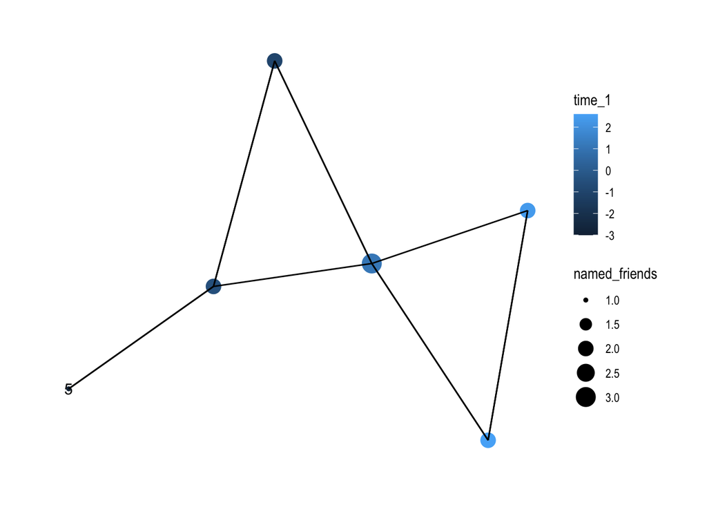

```r
#YOUR CODE HERE
student_network |>
ggraph() +
 # geom_node_text(aes(label = nominator)) +
  geom_node_text(aes(label = nominee)) +
  geom_node_point(aes(size = named_friends,
                      color = time_1)) +
  geom_edge_link() +
  theme_graph()
```

Based on the the mean exposure calculated above, and the sociogram you just created, what predictions do you have about how students attitudes might change at time 2?

Congrats! You made it to the end of the Explore section and are ready to learn a little about modeling network influence processes using simple linear regression!